# si544-day10-hypothesis-testing

Drew Pappas

11/8/2019

```r
library(tidyverse)
```

```r
library(infer)
library(moderndive)
library(nycflights13)
library(ggplot2movies)
library(knitr)
```

## Promotions

Let’s take a look at the promotions data:

```r
promotions
```

```
## # A tibble: 48 x 3
##       id decision gender
##    <int> <fct>    <fct>
##  1     1 promoted male
##  2     2 promoted male
##  3     3 promoted male
##  4     4 promoted male
##  5     5 promoted male
##  6     6 promoted male
##  7     7 promoted male
##  8     8 promoted male
##  9     9 promoted male
## 10    10 promoted male
## # ... with 38 more rows
```

Not helpful? Try taking a random sample (hint: sample_n() should help you)

As usual, let’s visualize our data:

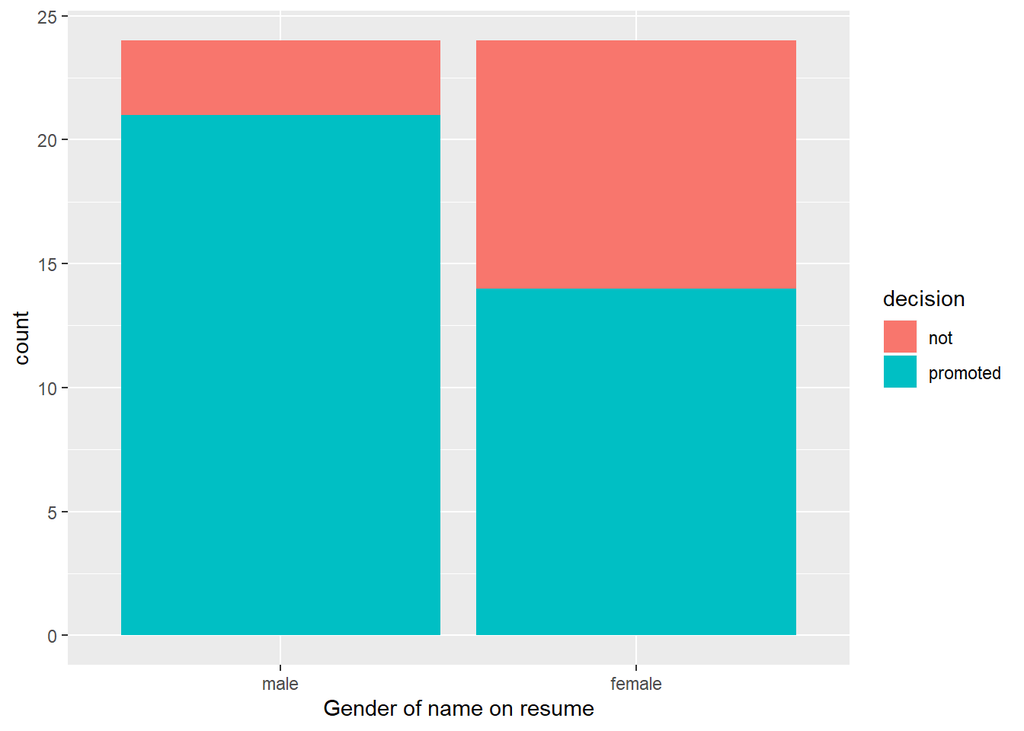

```r
## ----promotions-barplot, fig.cap="Barplot of relationship between gender and promotion decision."----
ggplot(promotions, aes(x = gender, fill = decision)) +
  geom_bar() +
  labs(x = "Gender of name on resume")
```

Let’s summarize our data:

```r
promotions %>%
  group_by(gender, decision) %>%
  summarize(n = n())
```

```
## # A tibble: 4 x 3
## # Groups:   gender [2]
##   gender decision     n
##   <fct>  <fct>    <int>
## 1 male   not          3
## 2 male   promoted    21
## 3 female not         10
## 4 female promoted    14
```

```r
observed_test_statistic <- promotions %>%
  specify(decision ~ gender, success = "promoted") %>%
  calculate(stat = "diff in props", order = c("male", "female")) %>%
  pull(stat) %>%
  round(3)
observed_test_statistic
```

```
## [1] 0.292
```

Let’s set a random seed so we can get reproducible results

```r
set.seed(2019)
```

```r
# Pick out 6 rows
promotions_sample <- promotions %>%
  slice(c(1, 5, 6, 20, 21, 47))
# Shuffle these 6 rows
promotions_sample_shuffled <- promotions_sample %>%
  mutate(gender = sample(gender))
```

## Shuffled

```r
promotions_shuffled
```

```
## # A tibble: 48 x 3
##       id decision gender
##    <int> <fct>    <fct>
##  1     1 promoted female
##  2     2 promoted female
##  3     3 promoted male
##  4     4 promoted female
##  5     5 promoted male
##  6     6 promoted male
##  7     7 promoted male
##  8     8 promoted female
##  9     9 promoted male
## 10    10 promoted female
## # ... with 38 more rows
```

Visualize our shuffled dataset:

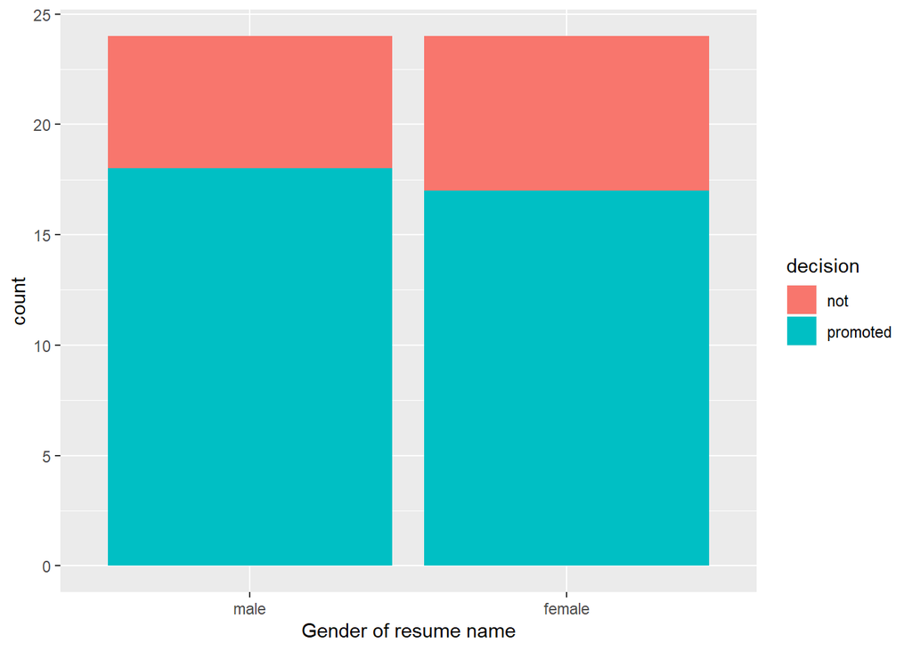

```r
ggplot(promotions_shuffled, aes(x = gender, fill = decision)) +
 geom_bar() +
 labs(x = "Gender of resume name")
```

The next block just calculates a variable that we need to the subsequent visualization:

```r
height1 <- promotions %>%
  group_by(gender, decision) %>%
  summarize(n = n()) %>%
  pull(n) %>%
  max()

height2 <- promotions_shuffled %>%
  group_by(gender, decision) %>%
  summarize(n = n()) %>%
  pull(n) %>%
  max()
height <- max(height1, height2)
height
```

```
## [1] 21
```

Let’s look at the non-shuffled and shuffled data:

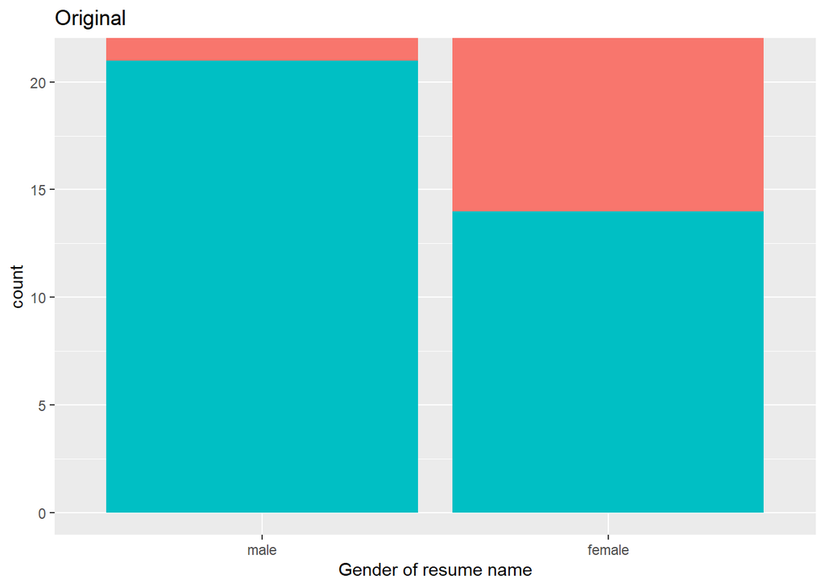

```r
plot1 <- ggplot(promotions, aes(x = gender, fill = decision)) +
  geom_bar() +
  labs(x = "Gender of resume name", title = "Original") +
  theme(legend.position = "none") +
  coord_cartesian(ylim= c(0, height))
plot2 <- ggplot(promotions_shuffled, aes(x = gender, fill = decision)) +
  geom_bar() +
  labs(x = "Gender of resume name", y ="", title = "Shuffled") +
  coord_cartesian(ylim= c(0, height))
# plot1 + plot2
plot1
```

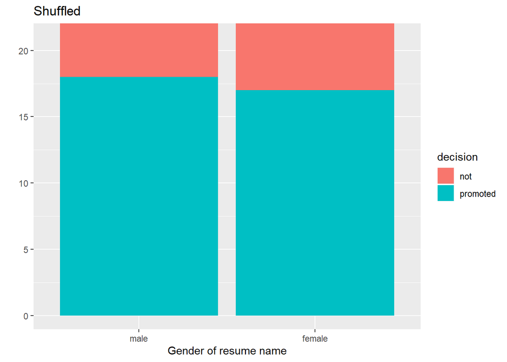

```r
plot2
```

```r
promotions_shuffled %>%
  group_by(gender, decision) %>%
  summarize(n = n())
```

```
## # A tibble: 4 x 3
## # Groups:   gender [2]
##   gender decision     n
##   <fct>  <fct>    <int>
## 1 male   not          6
## 2 male   promoted    18
## 3 female not          7
## 4 female promoted    17
```

```r
# male stats
n_men_promoted <- promotions_shuffled %>%
  filter(decision == "promoted", gender == "male") %>%
  nrow()
n_men_not_promoted <- promotions_shuffled %>%
  filter(decision == "not", gender == "male") %>%
  nrow()
prop_men_promoted <- n_men_promoted/(n_men_promoted + n_men_not_promoted)
```

```r
# female stats
n_women_promoted <- promotions_shuffled %>%
  filter(decision == "promoted", gender == "female") %>%
  nrow()
n_women_not_promoted <- promotions_shuffled %>%
  filter(decision == "not", gender == "female") %>%
  nrow()
prop_women_promoted <- n_women_promoted/(n_women_promoted + n_women_not_promoted)
```

```r
# diff
diff_prop <- round(prop_men_promoted - prop_women_promoted, 3)
diff_prop
```

```
## [1] 0.042
```

```r
# round propotions post difference
prop_men_promoted <- round(prop_men_promoted, 3)
prop_women_promoted <- round(prop_women_promoted, 3)
```

```r
if(!file.exists("shuffled_data.rds")){
  shuffled_data <- read_csv("https://docs.google.com/spreadsheets/d/e/2PACX-1vQXLJxwSp1ALEJ1JRNn3o8K3jVdqRG_5yxpoOhIFYflbFIkb2ttH73w8mljptn12CsDyIvjr5p0IGUe/pub?gid=0&single=true&output=csv")
  write_rds(shuffled_data, "shuffled_data.rds")
} else {
  shuffled_data <- read_rds("shuffled_data.rds")
}
```

## Observed Differences

```r
obs_diff_prop <- promotions %>%
 specify(decision ~ gender, success = "promoted") %>%
 calculate(stat = "diff in props", order = c("male", "female"))
obs_diff_prop
```

```
## # A tibble: 1 x 1
##    stat
##   <dbl>
## 1 0.292
```

```r
alpha <- 0.001 #Not used today
```

```r
promotions %>%
  specify(formula = decision ~ gender, success = "promoted")
```

```
## Response: decision (factor)
## Explanatory: gender (factor)
## # A tibble: 48 x 2
##    decision gender
##    <fct>    <fct>
##  1 promoted male
##  2 promoted male
##  3 promoted male
##  4 promoted male
##  5 promoted male
##  6 promoted male
##  7 promoted male
##  8 promoted male
##  9 promoted male
## 10 promoted male
## # ... with 38 more rows
```

```r
promotions %>%
  specify(formula = decision ~ gender, success = "promoted") %>%
  hypothesize(null = "independence")
```

```
## Response: decision (factor)
## Explanatory: gender (factor)
## Null Hypothesis: independence
## # A tibble: 48 x 2
##    decision gender
##    <fct>    <fct>
##  1 promoted male
##  2 promoted male
##  3 promoted male
##  4 promoted male
##  5 promoted male
##  6 promoted male
##  7 promoted male
##  8 promoted male
##  9 promoted male
## 10 promoted male
## # ... with 38 more rows
```

```r
promotions %>%
 specify(formula = decision ~ gender, success = "promoted") %>%
 hypothesize(null = "independence") %>%
 generate(reps = 1000, type = "permute")
```

```
## Response: decision (factor)
## Explanatory: gender (factor)
## Null Hypothesis: independence
## # A tibble: 48,000 x 3
## # Groups:   replicate [1,000]
##    decision gender replicate
##    <fct>    <fct>      <int>
##  1 promoted male           1
##  2 promoted male           1
##  3 promoted male           1
##  4 promoted male           1
##  5 not      male           1
##  6 promoted male           1
##  7 promoted male           1
##  8 promoted male           1
##  9 not      male           1
## 10 promoted male           1
## # ... with 47,990 more rows
```

```r
null_distribution <- promotions %>%
 specify(formula = decision ~ gender, success = "promoted") %>%
 hypothesize(null = "independence") %>%
 generate(reps = 1000, type = "permute") %>%
 calculate(stat = "diff in props", order = c("male", "female"))
null_distribution
```

```
## # A tibble: 1,000 x 2
##    replicate    stat
##        <int>   <dbl>
##  1         1 -0.125
##  2         2 -0.0417
##  3         3 -0.0417
##  4         4 -0.0417
##  5         5 -0.0417
##  6         6  0.208
##  7         7 -0.125
##  8         8  0.125
##  9         9 -0.0417
## 10        10  0.208
## # ... with 990 more rows
```

```r
obs_diff_prop <- promotions %>%
  specify(decision ~ gender, success = "promoted") %>%
  calculate(stat = "diff in props", order = c("male", "female"))
obs_diff_prop
```

```
## # A tibble: 1 x 1
##    stat
##   <dbl>
## 1 0.292
```

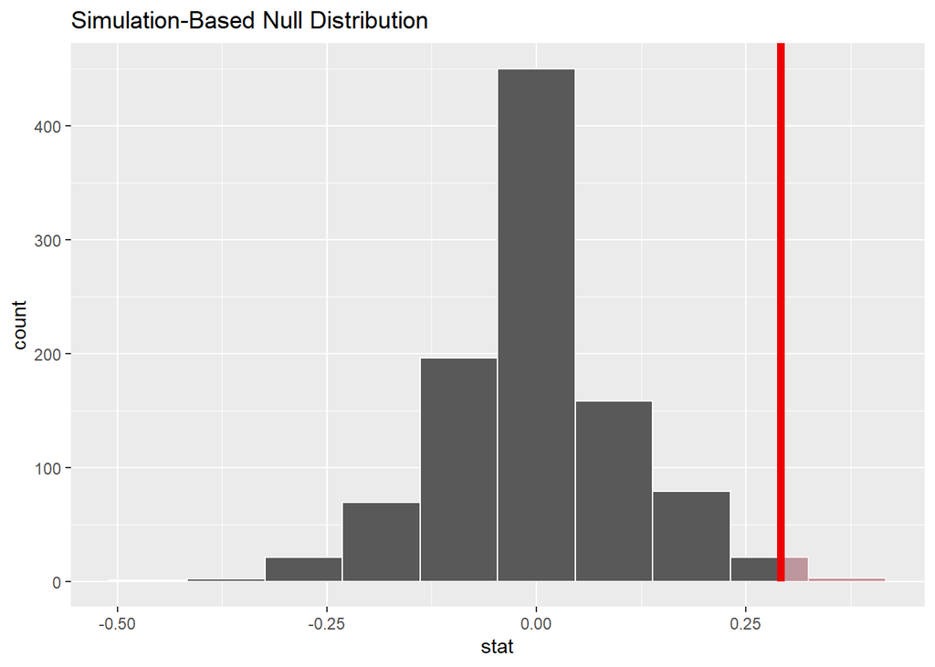

```r
visualize(null_distribution, bins = 10) +
  shade_p_value(obs_stat = obs_diff_prop, direction = "right")
```

```r
null_distribution %>%
  get_p_value(obs_stat = obs_diff_prop, direction = "right")
```

```
## # A tibble: 1 x 1
##   p_value
##     <dbl>
## 1   0.024
```

```r
p_value <- null_distribution %>%
  get_p_value(obs_stat = obs_diff_prop, direction = "right") %>%
  mutate(p_value = round(p_value, 3))
p_value
```

```
## # A tibble: 1 x 1
##   p_value
##     <dbl>
## 1   0.024
```

```r
null_distribution <- promotions %>%
 specify(formula = decision ~ gender, success = "promoted") %>%
 hypothesize(null = "independence") %>%
 generate(reps = 1000, type = "permute") %>%
 calculate(stat = "diff in props", order = c("male", "female"))
```

## Bootstrap distribution

```r
bootstrap_distribution <- promotions %>%
 specify(formula = decision ~ gender, success = "promoted") %>%
 # Change 1 - Remove hypothesize():
 # hypothesize(null = "independence") %>%
 # Change 2 - Switch type from "permute" to "bootstrap":
 generate(reps = 1000, type = "bootstrap") %>%
 calculate(stat = "diff in props", order = c("male", "female"))
```

```r
percentile_ci <- bootstrap_distribution %>%
  get_confidence_interval(level = 0.95, type = "percentile")
percentile_ci
```

```
## # A tibble: 1 x 2
##   `2.5%` `97.5%`
##    <dbl>   <dbl>
## 1 0.0473   0.520
```

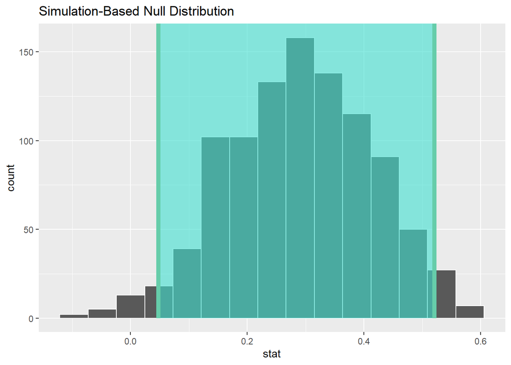

```r
visualize(bootstrap_distribution) +
 shade_confidence_interval(endpoints = percentile_ci)
```

```r
se_ci <- bootstrap_distribution %>%
  get_confidence_interval(level = 0.95, type = "se",
                          point_estimate = obs_diff_prop)
se_ci
```

```
## # A tibble: 1 x 2
##    lower upper
##    <dbl> <dbl>
## 1 0.0516 0.532
```

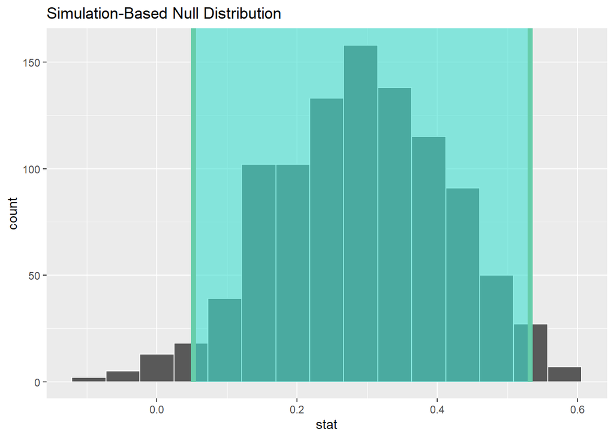

```r
visualize(bootstrap_distribution) +
 shade_confidence_interval(endpoints = se_ci)
```

## Learning Check 544.10.1

Consider the null hypothesis (that there is no gender-based difference in promotion rates) under three different alpha values: 0.001, 0.01 and 0.05. What inferences would you make about the proportion of promotions under each of these alpha values? Compare the analytic approach (using hypothesis testing and p-values) to the visual approach (using confidence intervals). Describe the difficulties in interpreting the results.

We can see visually with the plots above that when shaded, if p is greater than the alpha, it will fall within the shaded portion of the plot. It is within the confidence interval. If it is not greater than alpha, it will fall outside of the shaded area indicating it is not within the confidence interval. When using a visual method, it can be difficult to see whether or not the population proportion observed falls within the interval if the proportion observed is very close to the edges of the interval.

It is difficult to say whether or not we can reject the null hypothesis or fail to reject it as it depends on the alpha specified. If we are okay with being wrong, we can apply a 0.05 alpha and run the risk that our proportion is incorrect (a type 1 error where we incorrectly reject the null). If it is more important to reduce the risk of type 1 errors, we would increase the alpha value (and increase the possibility of type 2 errors).